# Wrangle SPINS gradients

Grabbing SPINS gradients

```r
library(tidyverse)
```

## Read in the SPINS big table

```r
spins_grads <- read_csv("../spins_concat_full")
# spins_grads <- spins_grads %>%
#   mutate(site = str_sub(`Subject`, 5, 7)) %>%
#   rename(task = `EA or RS`,
#          subject = `Subject ID`)
```

## read subject data

```r
lol_spins_behav <-
  read_csv('../data/spins_lolivers_subject_info_for_grads_2021-07-29.csv')
```

## grab some network colours

```r
networks <- read_delim("../networks.txt",
    "\t", escape_double = FALSE, trim_ws = TRUE) %>%
  select(NETWORK, NETWORKKEY, RED, GREEN, BLUE, ALPHA) %>%
  distinct() %>%
  add_row(NETWORK = "Subcortical", NETWORKKEY = 13, RED = 0, GREEN=0, BLUE=0, ALPHA=255) %>%
  mutate(hex = rgb(RED, GREEN, BLUE, maxColorValue = 255)) %>%
  arrange(NETWORKKEY)
networks
```

| NETWORK | NETWORKKEY | RED | GREEN | BLUE | ALPHA | hex |
| --- | --- | --- | --- | --- | --- | --- |
| Visual1 | 1 | 0 | 0 | 255 | 255 | #0000FF |
| Visual2 | 2 | 100 | 0 | 255 | 255 | #6400FF |
| Somatomotor | 3 | 0 | 255 | 255 | 255 | #00FFFF |
| Cingulo-Opercular | 4 | 153 | 0 | 153 | 255 | #990099 |
| Dorsal-Attention | 5 | 0 | 255 | 0 | 255 | #00FF00 |
| Language | 6 | 0 | 155 | 155 | 255 | #009B9B |
| Frontoparietal | 7 | 255 | 255 | 0 | 255 | #FFFF00 |
| Auditory | 8 | 250 | 62 | 251 | 255 | #FA3EFB |
| Default | 9 | 255 | 0 | 0 | 255 | #FF0000 |
| Posterior-Multimodal | 10 | 177 | 89 | 40 | 255 | #B15928 |

[output cut: 3 more lines]

## fitting models

Models

- model includes DX, sex, age, scanner, fd?
- what about between task -
  - do paired ttest?

So the current df is here: /projects/loliver/SPINS_PLS_Conn/data/processed/spins_behav_ea_conn_04-29-2021.csv 6:27 However, I also excluded ZHP_0110 and ZHP_0172 as they did not complete the soc cog tasks 6:27 So that df includes 356, but my current N is 354

The following participants were missing task-rest cleaned files: sub-CMP0180 sub-CMP0182 sub-CMP0191 sub-CMP0196 sub-CMP0198 sub-CMP0207 sub-CMP0213 sub-ZHH0034

The following participants were missing task-emp background files: sub-CMH0025 sub-CMH0044 sub-CMH0095 sub-CMH0138 sub-MRC0075 sub-MRP0077 sub-MRP0147 sub-MRP0149 sub-MRP0151 sub-MRP0161 sub-ZHH0038 sub-ZHP0061 sub-ZHP0086

```r
grand_mean_grads <- spins_grads %>%
  mutate(Network = factor(Network, levels = networks$NETWORK)) %>%
  filter(Subject %in% lol_spins_behav$subject) %>%
  group_by(Site, Task, ROI, Network) %>%
  summarise_at(vars(starts_with("grad")), mean)

grand_mean_grads
```

| Site | Task | ROI | Network | grad1 | grad2 | grad3 | grad4 | grad5 | grad6 | grad7 | grad8 | grad9 | grad10 |
| --- | --- | --- | --- | --- | --- | --- | --- | --- | --- | --- | --- | --- | --- |
| CMH | EA | aCAU-lh | Subcortical | 1.859073e-01 | -6.779414e-02 | 1.295815e-01 | 8.182364e-02 | 1.226816e-02 | 7.532929e-03 | -1.749270e-01 | 8.361626e-02 | -5.271931e-02 | -6.798673e-03 |
| CMH | EA | aCAU-rh | Subcortical | 1.708395e-01 | -5.887910e-02 | 1.537400e-01 | 8.090265e-02 | 7.714174e-03 | 9.590950e-04 | -1.515074e-01 | 6.127673e-02 | -5.992728e-02 | -1.613159e-02 |
| CMH | EA | aGP-lh | Subcortical | 4.208045e-02 | -4.170181e-02 | 6.417032e-02 | 3.104971e-02 | 3.133827e-02 | 2.135901e-02 | -4.064119e-02 | 4.853456e-02 | -4.918847e-02 | -1.451593e-02 |
| CMH | EA | aGP-rh | Subcortical | 2.312260e-02 | -5.049263e-02 | 6.116584e-02 | 4.598196e-02 | 4.407252e-02 | 6.627485e-03 | -3.286000e-02 | 3.329953e-02 | -3.636545e-02 | -1.331357e-02 |
| CMH | EA | aHIP-lh | Subcortical | 1.203379e-01 | -5.843642e-02 | -2.811523e-01 | -2.675253e-03 | 1.816299e-01 | -4.326974e-02 | 1.663491e-01 | 7.208093e-02 | -8.086198e-02 | -1.176439e-01 |
| CMH | EA | aHIP-rh | Subcortical | 1.186583e-01 | -4.791300e-02 | -2.862430e-01 | 7.983521e-04 | 1.640584e-01 | -4.007823e-02 | 1.607639e-01 | 5.983436e-02 | -8.407291e-02 | -1.140886e-01 |
| CMH | EA | aPUT-lh | Subcortical | 2.080594e-02 | -1.097414e-01 | 8.590851e-02 | 9.900500e-02 | 3.157792e-02 | 2.803349e-02 | -1.112908e-01 | 6.264078e-02 | -3.909914e-02 | -2.305474e-02 |
| CMH | EA | aPUT-rh | Subcortical | 1.726000e-02 | -1.146699e-01 | 7.799714e-02 | 1.108033e-01 | 3.479366e-02 | 5.794906e-03 | -9.083951e-02 | 4.066531e-02 | -3.851086e-02 | -2.183607e-02 |
| CMH | EA | L_1_ROI | Somatomotor | -2.421196e-01 | -1.792971e-01 | -4.471314e-03 | -1.643355e-01 | -6.121973e-02 | 1.398239e-01 | -9.286163e-02 | -5.523857e-03 | 3.696699e-03 | 9.985344e-03 |
| CMH | EA | L_10d_ROI | Default | 3.639401e-01 | -4.885995e-02 | -1.595296e-01 | 1.129918e-01 | -4.005812e-02 | 1.304554e-01 | -2.644907e-02 | -1.513595e-02 | 7.901903e-03 | -1.579947e-03 |

[output cut: 4694 more lines]

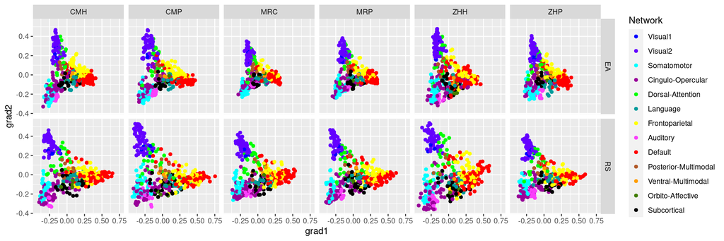

```r
grand_mean_grads %>%
  ggplot(aes(x = grad1, y = grad2, colour = Network)) +
  geom_point() +
  scale_color_manual(values = networks$hex) +
  facet_grid(Task ~ Site)
```

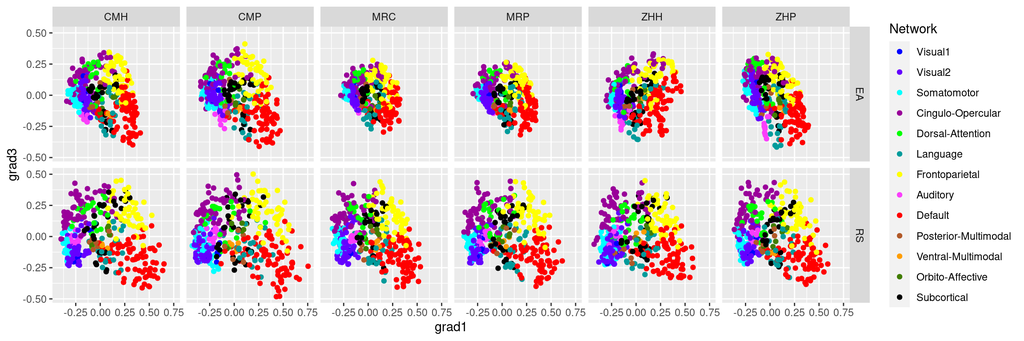

```r
grand_mean_grads %>%
  ggplot(aes(x = grad1, y = grad3, colour = Network)) +
  geom_point() +
  scale_color_manual(values = networks$hex) +
  facet_grid(Task ~ Site)
```

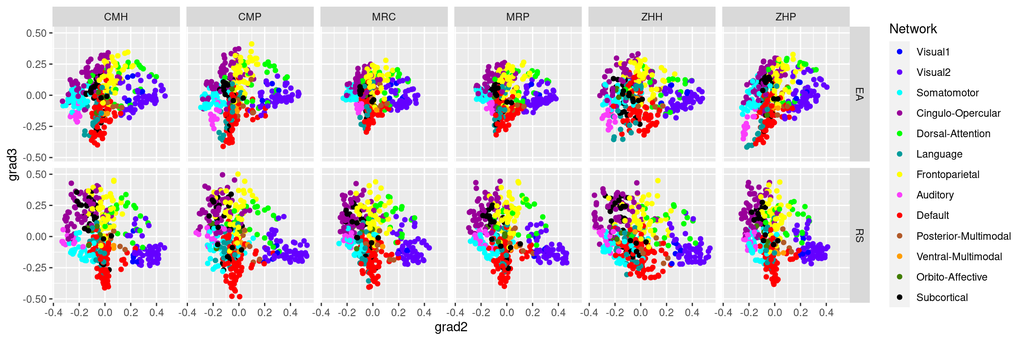

```r
grand_mean_grads %>%
  ggplot(aes(x = grad2, y = grad3, colour = Network)) +
  geom_point() +
  scale_color_manual(values = networks$hex) +
  facet_grid(Task ~ Site)
```

From age paper: Each axis of this 3D space was defined by the values along the first three gradients. Within network dispersion was quantified as sum squared Euclidean distance of network nodes to the network centroid at individual level. Between network dispersion was calculated as the Euclidean distance between network centroids.

They also did linear models on nodal values from the first three gradients

## calculating centroid and within network dispersion

```r
## calculate the network centers
subject_level_centers <- spins_grads %>%
  filter(Subject %in% lol_spins_behav$subject) %>%
  group_by(Site, Task, Network, Subject) %>%
  summarise_at(c("grad1", "grad2", "grad3"), mean)

subject_within_dispersion <- subject_level_centers %>%

  ## combine with orig spins grads
  inner_join(spins_grads, by = c("Site", "Task", "Network", "Subject"), suffix = c("_center", "")) %>%

  ## calculate squared euclidian distance from the network centroid
  ungroup() %>%
  mutate(roi_distance_sq = (grad1_center - grad1)**2 + (grad2_center - grad2)**2 + (grad3_center - grad3)**2) %>%

  ## dispersion as the sum of the squared distances within network and participant
  group_by(Site, Task, Network, Subject) %>%
  summarise(within_dispersion = sum(roi_distance_sq))
```

## calculating between network dispersion

Between network dispersion was calculated as the Euclidean distance between network centroids.

```r
library(igraph)
## assumes that the network_centroids contains columns "Network", "grad1", "grad2", "grad3"
calc_between_distances <- function(network_centoids) {
  ## grab the unique network node names
  network_names <- unique(network_centoids$Network)

  ## create a graph dataframe of edges
  result <- make_full_graph(length(network_names), directed = FALSE) %>% as_data_frame()

  for (i in 1:nrow(result)) {
    to_name <- network_names[result$to[i]]
    from_name <- network_names[result$from[i]]

    result$to_name[i] <- to_name
    result$from_name[i] <- from_name

  res_df <- test_centroids %>%
    filter(Network == to_name | Network == from_name) %>%
    mutate_at(vars(c("grad1", "grad2", "grad3")), function(x) {(x - lag(x))**2}) %>%
    mutate(eucl_dist = sqrt(grad1 + grad2 + grad3))

  result$eucl_dist[i] <- res_df$eucl_dist[2]

  }

  return(result %>% select(to_name, from_name, eucl_dist))
}
```

```r
between_network <- subject_level_centers %>%
  ungroup() %>%
  group_by(Site, Task, Subject) %>%
  nest() %>%
  mutate(distances = map(data, calc_between_distances))
```

```r
library(broom)
subject_level_centers %>%
  inner_join(lol_spins_behav, by = c("Subject" = "subject")) %>%
  mutate( fd_mean = if_else(Task=="EA", fd_mean_emp, `fd_mean.rest_bold`)) %>%
  ungroup() %>%
  group_by(Network) %>%
  do(tidy(aov(grad1 ~ Task + fd_mean_emp + scanner + Error(Subject), data = .))) %>%
  knitr::kable()
```

| Network | stratum | term | df | sumsq | meansq | statistic | p.value |
| --- | --- | --- | --- | --- | --- | --- | --- |
| Auditory | Subject | fd_mean_emp | 1 | 0.2410566 | 0.2410566 | 16.7359823 | 0.0000537 |
| Auditory | Subject | scanner | 5 | 0.9695118 | 0.1939024 | 13.4621762 | 0.0000000 |
| Auditory | Subject | Residuals | 340 | 4.8971877 | 0.0144035 | NA | NA |
| Auditory | Within | Task | 1 | 1.7395068 | 1.7395068 | 169.2665709 | 0.0000000 |
| Auditory | Within | Residuals | 346 | 3.5557485 | 0.0102767 | NA | NA |
| Cingulo-Opercular | Subject | fd_mean_emp | 1 | 0.1798410 | 0.1798410 | 26.9667235 | 0.0000004 |
| Cingulo-Opercular | Subject | scanner | 5 | 0.1300479 | 0.0260096 | 3.9000733 | 0.0018856 |
| Cingulo-Opercular | Subject | Residuals | 340 | 2.2674594 | 0.0066690 | NA | NA |
| Cingulo-Opercular | Within | Task | 1 | 0.6059721 | 0.6059721 | 121.3071681 | 0.0000000 |
| Cingulo-Opercular | Within | Residuals | 346 | 1.7283921 | 0.0049954 | NA | NA |
| Default | Subject | fd_mean_emp | 1 | 0.3362718 | 0.3362718 | 27.5756021 | 0.0000003 |
| Default | Subject | scanner | 5 | 0.1502482 | 0.0300496 | 2.4641889 | 0.0327104 |
| Default | Subject | Residuals | 340 | 4.1461434 | 0.0121945 | NA | NA |
| Default | Within | Task | 1 | 1.9149226 | 1.9149226 | 216.3837821 | 0.0000000 |
| Default | Within | Residuals | 346 | 3.0619818 | 0.0088497 | NA | NA |
| Dorsal-Attention | Subject | fd_mean_emp | 1 | 0.0187951 | 0.0187951 | 3.4755094 | 0.0631451 |
| Dorsal-Attention | Subject | scanner | 5 | 0.0858174 | 0.0171635 | 3.1737888 | 0.0081588 |
| Dorsal-Attention | Subject | Residuals | 340 | 1.8386797 | 0.0054079 | NA | NA |
| Dorsal-Attention | Within | Task | 1 | 0.0000205 | 0.0000205 | 0.0045249 | 0.9464076 |
| Dorsal-Attention | Within | Residuals | 346 | 1.5651070 | 0.0045234 | NA | NA |
| Frontoparietal | Subject | fd_mean_emp | 1 | 0.1420606 | 0.1420606 | 16.9432239 | 0.0000484 |
| Frontoparietal | Subject | scanner | 5 | 0.2858969 | 0.0571794 | 6.8196459 | 0.0000044 |
| Frontoparietal | Subject | Residuals | 340 | 2.8507332 | 0.0083845 | NA | NA |
| Frontoparietal | Within | Task | 1 | 2.1004711 | 2.1004711 | 351.1999223 | 0.0000000 |
| Frontoparietal | Within | Residuals | 346 | 2.0693712 | 0.0059808 | NA | NA |
| Language | Subject | fd_mean_emp | 1 | 0.0723941 | 0.0723941 | 7.2144678 | 0.0075867 |
| Language | Subject | scanner | 5 | 0.1296008 | 0.0259202 | 2.5830857 | 0.0260258 |
| Language | Subject | Residuals | 340 | 3.4117540 | 0.0100346 | NA | NA |
| Language | Within | Task | 1 | 0.0604718 | 0.0604718 | 7.6277963 | 0.0060543 |
| Language | Within | Residuals | 346 | 2.7430268 | 0.0079278 | NA | NA |
| Orbito-Affective | Subject | fd_mean_emp | 1 | 0.0222987 | 0.0222987 | 1.6614107 | 0.1982892 |
| Orbito-Affective | Subject | scanner | 5 | 0.1191457 | 0.0238291 | 1.7754381 | 0.1172360 |
| Orbito-Affective | Subject | Residuals | 340 | 4.5633273 | 0.0134216 | NA | NA |
| Orbito-Affective | Within | Task | 1 | 0.1609430 | 0.1609430 | 15.4296614 | 0.0001034 |
| Orbito-Affective | Within | Residuals | 346 | 3.6090406 | 0.0104308 | NA | NA |
| Posterior-Multimodal | Subject | fd_mean_emp | 1 | 0.0494498 | 0.0494498 | 2.7963719 | 0.0953978 |
| Posterior-Multimodal | Subject | scanner | 5 | 0.1040379 | 0.0208076 | 1.1766636 | 0.3202170 |
| Posterior-Multimodal | Subject | Residuals | 340 | 6.0124033 | 0.0176835 | NA | NA |
| Posterior-Multimodal | Within | Task | 1 | 0.1829712 | 0.1829712 | 18.4440109 | 0.0000228 |
| Posterior-Multimodal | Within | Residuals | 346 | 3.4324448 | 0.0099204 | NA | NA |
| Somatomotor | Subject | fd_mean_emp | 1 | 0.3170021 | 0.3170021 | 29.2506751 | 0.0000001 |
| Somatomotor | Subject | scanner | 5 | 0.1444326 | 0.0288865 | 2.6654401 | 0.0221903 |
| Somatomotor | Subject | Residuals | 340 | 3.6847260 | 0.0108374 | NA | NA |
| Somatomotor | Within | Task | 1 | 1.5196513 | 1.5196513 | 207.1846564 | 0.0000000 |
| Somatomotor | Within | Residuals | 346 | 2.5378296 | 0.0073348 | NA | NA |
| Subcortical | Subject | fd_mean_emp | 1 | 0.0278134 | 0.0278134 | 4.5982570 | 0.0327130 |
| Subcortical | Subject | scanner | 5 | 0.0338587 | 0.0067717 | 1.1195417 | 0.3496251 |
| Subcortical | Subject | Residuals | 340 | 2.0565494 | 0.0060487 | NA | NA |
| Subcortical | Within | Task | 1 | 0.0612662 | 0.0612662 | 11.3017163 | 0.0008609 |
| Subcortical | Within | Residuals | 346 | 1.8756523 | 0.0054210 | NA | NA |
| Ventral-Multimodal | Subject | fd_mean_emp | 1 | 0.1318945 | 0.1318945 | 7.7997520 | 0.0055211 |
| Ventral-Multimodal | Subject | scanner | 5 | 0.1345269 | 0.0269054 | 1.5910841 | 0.1619279 |
| Ventral-Multimodal | Subject | Residuals | 340 | 5.7494308 | 0.0169101 | NA | NA |
| Ventral-Multimodal | Within | Task | 1 | 0.3395372 | 0.3395372 | 21.2944836 | 0.0000056 |
| Ventral-Multimodal | Within | Residuals | 346 | 5.5169152 | 0.0159448 | NA | NA |
| Visual1 | Subject | fd_mean_emp | 1 | 0.0524464 | 0.0524464 | 3.3401567 | 0.0684845 |
| Visual1 | Subject | scanner | 5 | 0.1246001 | 0.0249200 | 1.5870836 | 0.1630480 |
| Visual1 | Subject | Residuals | 340 | 5.3386033 | 0.0157018 | NA | NA |
| Visual1 | Within | Task | 1 | 0.2547942 | 0.2547942 | 17.6412974 | 0.0000340 |
| Visual1 | Within | Residuals | 346 | 4.9972960 | 0.0144431 | NA | NA |
| Visual2 | Subject | fd_mean_emp | 1 | 0.0731544 | 0.0731544 | 11.0011824 | 0.0010089 |
| Visual2 | Subject | scanner | 5 | 0.1550530 | 0.0310106 | 4.6634676 | 0.0003935 |
| Visual2 | Subject | Residuals | 340 | 2.2608934 | 0.0066497 | NA | NA |
| Visual2 | Within | Task | 1 | 1.5891884 | 1.5891884 | 249.9492734 | 0.0000000 |
| Visual2 | Within | Residuals | 346 | 2.1998831 | 0.0063580 | NA | NA |

```r
results_subject_within_dispersion <- subject_within_dispersion %>%
  inner_join(lol_spins_behav, by = c("Subject" = "subject")) %>%
  mutate( fd_mean = if_else(Task=="EA", fd_mean_emp, `fd_mean.rest_bold`)) %>%
  group_by(Network, Task) %>%
  do(tidy(lm(within_dispersion ~ diagnostic_group + demo_age_study_entry + demo_sex + fd_mean + scanner, data = .))) %>%
  ungroup() %>%
  group_by(term) %>%
  mutate(p_FDR = p.adjust(p.value, method = "fdr"))

results_subject_within_dispersion %>%
  filter(term == "diagnostic_groupcontrol") %>%
  knitr::kable()
```

| Network | Task | term | estimate | std.error | statistic | p.value | p_FDR |
| --- | --- | --- | --- | --- | --- | --- | --- |
| Auditory | EA | diagnostic_groupcontrol | -0.0777345 | 0.0270933 | -2.8691404 | 0.0043755 | 0.0126405 |
| Auditory | RS | diagnostic_groupcontrol | -0.0870796 | 0.0735874 | -1.1833487 | 0.2375051 | 0.2806878 |
| Cingulo-Opercular | EA | diagnostic_groupcontrol | -0.3729309 | 0.1726554 | -2.1599728 | 0.0314795 | 0.0584619 |
| Cingulo-Opercular | RS | diagnostic_groupcontrol | -0.3996999 | 0.3579611 | -1.1166016 | 0.2649602 | 0.2995202 |
| Default | EA | diagnostic_groupcontrol | -1.2368823 | 0.2276989 | -5.4320959 | 0.0000001 | 0.0000014 |
| Default | RS | diagnostic_groupcontrol | -1.1576077 | 0.5190678 | -2.2301664 | 0.0263945 | 0.0527891 |
| Dorsal-Attention | EA | diagnostic_groupcontrol | -0.2005585 | 0.0760238 | -2.6381007 | 0.0087239 | 0.0206202 |
| Dorsal-Attention | RS | diagnostic_groupcontrol | -0.3787307 | 0.1822749 | -2.0778000 | 0.0384845 | 0.0625373 |
| Frontoparietal | EA | diagnostic_groupcontrol | -0.5015026 | 0.1355677 | -3.6992786 | 0.0002524 | 0.0011044 |
| Frontoparietal | RS | diagnostic_groupcontrol | -0.5040193 | 0.3170655 | -1.5896380 | 0.1128541 | 0.1625429 |
| Language | EA | diagnostic_groupcontrol | -0.3237295 | 0.0802990 | -4.0315512 | 0.0000686 | 0.0004456 |
| Language | RS | diagnostic_groupcontrol | -0.8070987 | 0.1455971 | -5.5433728 | 0.0000001 | 0.0000014 |
| Orbito-Affective | EA | diagnostic_groupcontrol | -0.0158362 | 0.0114933 | -1.3778589 | 0.1691611 | 0.2094375 |
| Orbito-Affective | RS | diagnostic_groupcontrol | -0.0749413 | 0.0356727 | -2.1008017 | 0.0364009 | 0.0625373 |
| Posterior-Multimodal | EA | diagnostic_groupcontrol | -0.0601386 | 0.0226541 | -2.6546490 | 0.0083158 | 0.0206202 |
| Posterior-Multimodal | RS | diagnostic_groupcontrol | -0.1417179 | 0.0563980 | -2.5128151 | 0.0124435 | 0.0269609 |
| Somatomotor | EA | diagnostic_groupcontrol | -0.1559361 | 0.0883857 | -1.7642672 | 0.0785929 | 0.1202009 |
| Somatomotor | RS | diagnostic_groupcontrol | -0.7857230 | 0.2149275 | -3.6557588 | 0.0002974 | 0.0011044 |
| Subcortical | EA | diagnostic_groupcontrol | -0.0683218 | 0.0835787 | -0.8174554 | 0.4142458 | 0.4308156 |
| Subcortical | RS | diagnostic_groupcontrol | 0.8399378 | 0.2774444 | 3.0274091 | 0.0026567 | 0.0086343 |
| Ventral-Multimodal | EA | diagnostic_groupcontrol | -0.0020830 | 0.0039017 | -0.5338572 | 0.5937923 | 0.5937923 |
| Ventral-Multimodal | RS | diagnostic_groupcontrol | -0.0316624 | 0.0202459 | -1.5638924 | 0.1187814 | 0.1625429 |
| Visual1 | EA | diagnostic_groupcontrol | -0.0123708 | 0.0129106 | -0.9581901 | 0.3386538 | 0.3668750 |
| Visual1 | RS | diagnostic_groupcontrol | -0.1674724 | 0.0386144 | -4.3370461 | 0.0000191 | 0.0001656 |
| Visual2 | EA | diagnostic_groupcontrol | -0.1733189 | 0.1202816 | -1.4409422 | 0.1505295 | 0.1956883 |
| Visual2 | RS | diagnostic_groupcontrol | -1.2402142 | 0.3362451 | -3.6884233 | 0.0002630 | 0.0011044 |

```r
results_subject_within_dispersion %>%
  filter(term == "demo_age_study_entry") %>%
  knitr::kable()
```

| Network | Task | term | estimate | std.error | statistic | p.value | p_FDR |
| --- | --- | --- | --- | --- | --- | --- | --- |
| Auditory | EA | demo_age_study_entry | 0.0014196 | 0.0014314 | 0.9917820 | 0.3220154 | 0.5693471 |
| Auditory | RS | demo_age_study_entry | 0.0072330 | 0.0039990 | 1.8086793 | 0.0713920 | 0.2320240 |
| Cingulo-Opercular | EA | demo_age_study_entry | -0.0333669 | 0.0091217 | -3.6579722 | 0.0002949 | 0.0076672 |
| Cingulo-Opercular | RS | demo_age_study_entry | -0.0090196 | 0.0194530 | -0.4636615 | 0.6431896 | 0.8338457 |
| Default | EA | demo_age_study_entry | -0.0171380 | 0.0120297 | -1.4246363 | 0.1551877 | 0.3668074 |
| Default | RS | demo_age_study_entry | 0.0072041 | 0.0282082 | 0.2553907 | 0.7985772 | 0.8804790 |
| Dorsal-Attention | EA | demo_age_study_entry | -0.0134694 | 0.0040165 | -3.3535275 | 0.0008887 | 0.0115529 |
| Dorsal-Attention | RS | demo_age_study_entry | -0.0116876 | 0.0099055 | -1.1799090 | 0.2388686 | 0.5175487 |
| Frontoparietal | EA | demo_age_study_entry | -0.0159576 | 0.0071623 | -2.2280071 | 0.0265396 | 0.0985757 |
| Frontoparietal | RS | demo_age_study_entry | -0.0111837 | 0.0172306 | -0.6490598 | 0.5167418 | 0.7585147 |
| Language | EA | demo_age_study_entry | 0.0008213 | 0.0042423 | 0.1935889 | 0.8466144 | 0.8804790 |
| Language | RS | demo_age_study_entry | 0.0050332 | 0.0079123 | 0.6361268 | 0.5251256 | 0.7585147 |
| Orbito-Affective | EA | demo_age_study_entry | 0.0000805 | 0.0006072 | 0.1324969 | 0.8946703 | 0.8946703 |
| Orbito-Affective | RS | demo_age_study_entry | 0.0046112 | 0.0019386 | 2.3786199 | 0.0179343 | 0.0932583 |
| Posterior-Multimodal | EA | demo_age_study_entry | -0.0018347 | 0.0011969 | -1.5329691 | 0.1262217 | 0.3281763 |
| Posterior-Multimodal | RS | demo_age_study_entry | -0.0008493 | 0.0030649 | -0.2771020 | 0.7818717 | 0.8804790 |
| Somatomotor | EA | demo_age_study_entry | -0.0019693 | 0.0046696 | -0.4217304 | 0.6734907 | 0.8338457 |
| Somatomotor | RS | demo_age_study_entry | -0.0269324 | 0.0116800 | -2.3058579 | 0.0217252 | 0.0941424 |
| Subcortical | EA | demo_age_study_entry | -0.0019178 | 0.0044156 | -0.4343260 | 0.6643297 | 0.8338457 |
| Subcortical | RS | demo_age_study_entry | -0.0361672 | 0.0150774 | -2.3987634 | 0.0169935 | 0.0932583 |
| Ventral-Multimodal | EA | demo_age_study_entry | 0.0001430 | 0.0002061 | 0.6935300 | 0.4884547 | 0.7585147 |
| Ventral-Multimodal | RS | demo_age_study_entry | 0.0030462 | 0.0011002 | 2.7686232 | 0.0059408 | 0.0514866 |
| Visual1 | EA | demo_age_study_entry | 0.0001361 | 0.0006821 | 0.1995673 | 0.8419394 | 0.8804790 |
| Visual1 | RS | demo_age_study_entry | -0.0035973 | 0.0020985 | -1.7142504 | 0.0874022 | 0.2524952 |
| Visual2 | EA | demo_age_study_entry | -0.0062188 | 0.0063547 | -0.9786206 | 0.3284695 | 0.5693471 |
| Visual2 | RS | demo_age_study_entry | -0.0201776 | 0.0182729 | -1.1042362 | 0.2702785 | 0.5405570 |

```r
net_centroids_results <- subject_level_centers %>%
  inner_join(lol_spins_behav, by = c("Subject" = "subject")) %>%
  mutate( fd_mean = if_else(Task=="EA", fd_mean_emp, `fd_mean.rest_bold`)) %>%

  pivot_longer(starts_with("grad"), names_to = "grad_num", values_to = "grad_value") %>%
    ungroup() %>%
  group_by(Network, Task, grad_num) %>%
  do(tidy(lm(grad_value ~ diagnostic_group + demo_age_study_entry + demo_sex + fd_mean + scanner, data = .))) %>%
  ungroup() %>%
  group_by(term) %>%
  mutate(p_FDR = p.adjust(p.value, method = "fdr"))

net_centroids_results %>%
  filter(term == "diagnostic_groupcontrol") %>%
  arrange(grad_num, Task) %>%
  knitr::kable()
```

| Network | Task | grad_num | term | estimate | std.error | statistic | p.value | p_FDR |
| --- | --- | --- | --- | --- | --- | --- | --- | --- |
| Auditory | EA | grad1 | diagnostic_groupcontrol | 0.0310248 | 0.0080033 | 3.8764975 | 0.0001274 | 0.0011040 |
| Cingulo-Opercular | EA | grad1 | diagnostic_groupcontrol | 0.0217005 | 0.0057016 | 3.8060303 | 0.0001677 | 0.0013081 |
| Default | EA | grad1 | diagnostic_groupcontrol | -0.0469927 | 0.0076417 | -6.1495270 | 0.0000000 | 0.0000002 |
| Dorsal-Attention | EA | grad1 | diagnostic_groupcontrol | 0.0091426 | 0.0049371 | 1.8518015 | 0.0649288 | 0.1389958 |
| Frontoparietal | EA | grad1 | diagnostic_groupcontrol | -0.0143003 | 0.0051377 | -2.7834341 | 0.0056821 | 0.0246224 |
| Language | EA | grad1 | diagnostic_groupcontrol | 0.0071599 | 0.0062203 | 1.1510608 | 0.2505232 | 0.3686946 |
| Orbito-Affective | EA | grad1 | diagnostic_groupcontrol | -0.0013512 | 0.0082215 | -0.1643490 | 0.8695549 | 0.8695549 |
| Posterior-Multimodal | EA | grad1 | diagnostic_groupcontrol | -0.0089557 | 0.0079798 | -1.1223014 | 0.2625333 | 0.3723199 |
| Somatomotor | EA | grad1 | diagnostic_groupcontrol | 0.0267055 | 0.0073147 | 3.6509229 | 0.0003028 | 0.0019681 |
| Subcortical | EA | grad1 | diagnostic_groupcontrol | 0.0033146 | 0.0046835 | 0.7077332 | 0.4796001 | 0.5755202 |
| Ventral-Multimodal | EA | grad1 | diagnostic_groupcontrol | -0.0068650 | 0.0089093 | -0.7705506 | 0.4415132 | 0.5554521 |
| Visual1 | EA | grad1 | diagnostic_groupcontrol | 0.0078660 | 0.0066533 | 1.1822671 | 0.2379332 | 0.3568998 |
| Visual2 | EA | grad1 | diagnostic_groupcontrol | 0.0157566 | 0.0052307 | 3.0123442 | 0.0027885 | 0.0127942 |
| Auditory | RS | grad1 | diagnostic_groupcontrol | 0.0586174 | 0.0149332 | 3.9253211 | 0.0001050 | 0.0010241 |
| Cingulo-Opercular | RS | grad1 | diagnostic_groupcontrol | 0.0527233 | 0.0094925 | 5.5542217 | 0.0000001 | 0.0000022 |
| Default | RS | grad1 | diagnostic_groupcontrol | -0.0540883 | 0.0129929 | -4.1629269 | 0.0000399 | 0.0004451 |
| Dorsal-Attention | RS | grad1 | diagnostic_groupcontrol | -0.0029137 | 0.0097662 | -0.2983505 | 0.7656195 | 0.7857674 |
| Frontoparietal | RS | grad1 | diagnostic_groupcontrol | -0.0157369 | 0.0118768 | -1.3250170 | 0.1860632 | 0.3154985 |
| Language | RS | grad1 | diagnostic_groupcontrol | -0.0142889 | 0.0132269 | -1.0802884 | 0.2807863 | 0.3842338 |
| Orbito-Affective | RS | grad1 | diagnostic_groupcontrol | 0.0063686 | 0.0149452 | 0.4261318 | 0.6702838 | 0.7261408 |
| Posterior-Multimodal | RS | grad1 | diagnostic_groupcontrol | -0.0137368 | 0.0166496 | -0.8250497 | 0.4099270 | 0.5241689 |
| Somatomotor | RS | grad1 | diagnostic_groupcontrol | 0.0235988 | 0.0125419 | 1.8815918 | 0.0607532 | 0.1389958 |
| Subcortical | RS | grad1 | diagnostic_groupcontrol | 0.0198439 | 0.0107563 | 1.8448689 | 0.0659339 | 0.1389958 |
| Ventral-Multimodal | RS | grad1 | diagnostic_groupcontrol | -0.0062968 | 0.0179262 | -0.3512630 | 0.7256105 | 0.7648327 |
| Visual1 | RS | grad1 | diagnostic_groupcontrol | -0.0444929 | 0.0179670 | -2.4763648 | 0.0137633 | 0.0511207 |
| Visual2 | RS | grad1 | diagnostic_groupcontrol | 0.0073694 | 0.0112700 | 0.6538954 | 0.5136251 | 0.5891582 |
| Auditory | EA | grad2 | diagnostic_groupcontrol | 0.0088975 | 0.0094103 | 0.9455117 | 0.3450751 | 0.4546031 |
| Cingulo-Opercular | EA | grad2 | diagnostic_groupcontrol | 0.0139250 | 0.0042637 | 3.2659581 | 0.0012031 | 0.0067028 |
| Default | EA | grad2 | diagnostic_groupcontrol | -0.0016134 | 0.0031054 | -0.5195400 | 0.6037253 | 0.6727225 |
| Dorsal-Attention | EA | grad2 | diagnostic_groupcontrol | -0.0124027 | 0.0049345 | -2.5134515 | 0.0124215 | 0.0484439 |
| Frontoparietal | EA | grad2 | diagnostic_groupcontrol | -0.0066334 | 0.0037649 | -1.7618832 | 0.0789957 | 0.1540415 |
| Language | EA | grad2 | diagnostic_groupcontrol | -0.0051559 | 0.0051979 | -0.9919298 | 0.3219434 | 0.4329584 |
| Orbito-Affective | EA | grad2 | diagnostic_groupcontrol | 0.0235387 | 0.0074302 | 3.1679736 | 0.0016755 | 0.0087126 |
| Posterior-Multimodal | EA | grad2 | diagnostic_groupcontrol | -0.0138424 | 0.0070737 | -1.9568846 | 0.0511864 | 0.1247669 |
| Somatomotor | EA | grad2 | diagnostic_groupcontrol | 0.0178212 | 0.0075253 | 2.3681794 | 0.0184397 | 0.0625347 |
| Subcortical | EA | grad2 | diagnostic_groupcontrol | 0.0066664 | 0.0053781 | 1.2395364 | 0.2160094 | 0.3373297 |
| Ventral-Multimodal | EA | grad2 | diagnostic_groupcontrol | -0.0039392 | 0.0085023 | -0.4633111 | 0.6434405 | 0.7068782 |
| Visual1 | EA | grad2 | diagnostic_groupcontrol | -0.0206171 | 0.0094075 | -2.1915501 | 0.0290960 | 0.0898867 |
| Visual2 | EA | grad2 | diagnostic_groupcontrol | -0.0145073 | 0.0073837 | -1.9647740 | 0.0502616 | 0.1247669 |
| Auditory | RS | grad2 | diagnostic_groupcontrol | -0.0158802 | 0.0145785 | -1.0892878 | 0.2768053 | 0.3842338 |
| Cingulo-Opercular | RS | grad2 | diagnostic_groupcontrol | -0.0117619 | 0.0086742 | -1.3559514 | 0.1760225 | 0.3067736 |
| Default | RS | grad2 | diagnostic_groupcontrol | -0.0087903 | 0.0056898 | -1.5449128 | 0.1233059 | 0.2236711 |
| Dorsal-Attention | RS | grad2 | diagnostic_groupcontrol | 0.0239873 | 0.0111756 | 2.1463947 | 0.0325550 | 0.0906890 |
| Frontoparietal | RS | grad2 | diagnostic_groupcontrol | -0.0147657 | 0.0067738 | -2.1798240 | 0.0299622 | 0.0898867 |
| Language | RS | grad2 | diagnostic_groupcontrol | 0.0205456 | 0.0096498 | 2.1291224 | 0.0339688 | 0.0913643 |
| Orbito-Affective | RS | grad2 | diagnostic_groupcontrol | -0.0181620 | 0.0134242 | -1.3529304 | 0.1769848 | 0.3067736 |
| Posterior-Multimodal | RS | grad2 | diagnostic_groupcontrol | 0.0258778 | 0.0140026 | 1.8480793 | 0.0654669 | 0.1389958 |
| Somatomotor | RS | grad2 | diagnostic_groupcontrol | 0.0141611 | 0.0124837 | 1.1343693 | 0.2574459 | 0.3718663 |
| Subcortical | RS | grad2 | diagnostic_groupcontrol | -0.0388677 | 0.0087794 | -4.4271610 | 0.0000129 | 0.0001679 |
| Ventral-Multimodal | RS | grad2 | diagnostic_groupcontrol | -0.0037812 | 0.0166904 | -0.2265485 | 0.8209122 | 0.8315734 |
| Visual1 | RS | grad2 | diagnostic_groupcontrol | -0.0083669 | 0.0203216 | -0.4117251 | 0.6808027 | 0.7274330 |
| Visual2 | RS | grad2 | diagnostic_groupcontrol | 0.0316221 | 0.0132626 | 2.3842974 | 0.0176646 | 0.0625347 |
| Auditory | EA | grad3 | diagnostic_groupcontrol | 0.0072938 | 0.0096736 | 0.7539885 | 0.4513826 | 0.5588547 |
| Cingulo-Opercular | EA | grad3 | diagnostic_groupcontrol | -0.0086673 | 0.0043483 | -1.9932462 | 0.0470404 | 0.1223050 |
| Default | EA | grad3 | diagnostic_groupcontrol | 0.0172674 | 0.0051221 | 3.3711417 | 0.0008355 | 0.0050130 |
| Dorsal-Attention | EA | grad3 | diagnostic_groupcontrol | -0.0087503 | 0.0053685 | -1.6299362 | 0.1040492 | 0.1979474 |
| Frontoparietal | EA | grad3 | diagnostic_groupcontrol | -0.0087371 | 0.0048406 | -1.8049787 | 0.0719705 | 0.1477289 |
| Language | EA | grad3 | diagnostic_groupcontrol | 0.0124939 | 0.0070598 | 1.7697238 | 0.0776774 | 0.1540415 |
| Orbito-Affective | EA | grad3 | diagnostic_groupcontrol | -0.0044681 | 0.0079100 | -0.5648621 | 0.5725434 | 0.6472229 |
| Posterior-Multimodal | EA | grad3 | diagnostic_groupcontrol | 0.0253088 | 0.0083767 | 3.0213455 | 0.0027090 | 0.0127942 |
| Somatomotor | EA | grad3 | diagnostic_groupcontrol | -0.0177409 | 0.0047660 | -3.7223947 | 0.0002312 | 0.0016394 |
| Subcortical | EA | grad3 | diagnostic_groupcontrol | 0.0149149 | 0.0057454 | 2.5959686 | 0.0098453 | 0.0404174 |
| Ventral-Multimodal | EA | grad3 | diagnostic_groupcontrol | -0.0030188 | 0.0090271 | -0.3344178 | 0.7382723 | 0.7678032 |
| Visual1 | EA | grad3 | diagnostic_groupcontrol | -0.0080610 | 0.0063203 | -1.2754006 | 0.2030460 | 0.3299497 |
| Visual2 | EA | grad3 | diagnostic_groupcontrol | -0.0021927 | 0.0032194 | -0.6810906 | 0.4962819 | 0.5865150 |
| Auditory | RS | grad3 | diagnostic_groupcontrol | 0.0123916 | 0.0132320 | 0.9364840 | 0.3496947 | 0.4546031 |
| Cingulo-Opercular | RS | grad3 | diagnostic_groupcontrol | -0.0192140 | 0.0082561 | -2.3272526 | 0.0205438 | 0.0667672 |
| Default | RS | grad3 | diagnostic_groupcontrol | 0.0374303 | 0.0070174 | 5.3339206 | 0.0000002 | 0.0000046 |
| Dorsal-Attention | RS | grad3 | diagnostic_groupcontrol | -0.0509798 | 0.0103405 | -4.9301195 | 0.0000013 | 0.0000240 |
| Frontoparietal | RS | grad3 | diagnostic_groupcontrol | -0.0176659 | 0.0081867 | -2.1578869 | 0.0316427 | 0.0906890 |
| Language | RS | grad3 | diagnostic_groupcontrol | -0.0069088 | 0.0103929 | -0.6647606 | 0.5066582 | 0.5891582 |
| Orbito-Affective | RS | grad3 | diagnostic_groupcontrol | 0.0256836 | 0.0139139 | 1.8458994 | 0.0657837 | 0.1389958 |
| Posterior-Multimodal | RS | grad3 | diagnostic_groupcontrol | -0.0230782 | 0.0147333 | -1.5663971 | 0.1181942 | 0.2195034 |
| Somatomotor | RS | grad3 | diagnostic_groupcontrol | -0.0061219 | 0.0086447 | -0.7081738 | 0.4793269 | 0.5755202 |
| Subcortical | RS | grad3 | diagnostic_groupcontrol | 0.0577707 | 0.0118061 | 4.8933127 | 0.0000015 | 0.0000240 |
| Ventral-Multimodal | RS | grad3 | diagnostic_groupcontrol | -0.0207722 | 0.0160670 | -1.2928454 | 0.1969502 | 0.3268534 |
| Visual1 | RS | grad3 | diagnostic_groupcontrol | -0.0166088 | 0.0137756 | -1.2056653 | 0.2287924 | 0.3499178 |
| Visual2 | RS | grad3 | diagnostic_groupcontrol | -0.0085996 | 0.0069412 | -1.2389209 | 0.2162370 | 0.3373297 |

```r
net_centroids_results %>%
  filter(term == "diagnostic_groupcontrol") %>%
  arrange(grad_num, Task) %>%
  knitr::kable()
```

| Network | Task | grad_num | term | estimate | std.error | statistic | p.value | p_FDR |
| --- | --- | --- | --- | --- | --- | --- | --- | --- |
| Auditory | EA | grad1 | diagnostic_groupcontrol | 0.0310248 | 0.0080033 | 3.8764975 | 0.0001274 | 0.0011040 |
| Cingulo-Opercular | EA | grad1 | diagnostic_groupcontrol | 0.0217005 | 0.0057016 | 3.8060303 | 0.0001677 | 0.0013081 |
| Default | EA | grad1 | diagnostic_groupcontrol | -0.0469927 | 0.0076417 | -6.1495270 | 0.0000000 | 0.0000002 |
| Dorsal-Attention | EA | grad1 | diagnostic_groupcontrol | 0.0091426 | 0.0049371 | 1.8518015 | 0.0649288 | 0.1389958 |
| Frontoparietal | EA | grad1 | diagnostic_groupcontrol | -0.0143003 | 0.0051377 | -2.7834341 | 0.0056821 | 0.0246224 |
| Language | EA | grad1 | diagnostic_groupcontrol | 0.0071599 | 0.0062203 | 1.1510608 | 0.2505232 | 0.3686946 |
| Orbito-Affective | EA | grad1 | diagnostic_groupcontrol | -0.0013512 | 0.0082215 | -0.1643490 | 0.8695549 | 0.8695549 |
| Posterior-Multimodal | EA | grad1 | diagnostic_groupcontrol | -0.0089557 | 0.0079798 | -1.1223014 | 0.2625333 | 0.3723199 |
| Somatomotor | EA | grad1 | diagnostic_groupcontrol | 0.0267055 | 0.0073147 | 3.6509229 | 0.0003028 | 0.0019681 |
| Subcortical | EA | grad1 | diagnostic_groupcontrol | 0.0033146 | 0.0046835 | 0.7077332 | 0.4796001 | 0.5755202 |
| Ventral-Multimodal | EA | grad1 | diagnostic_groupcontrol | -0.0068650 | 0.0089093 | -0.7705506 | 0.4415132 | 0.5554521 |
| Visual1 | EA | grad1 | diagnostic_groupcontrol | 0.0078660 | 0.0066533 | 1.1822671 | 0.2379332 | 0.3568998 |
| Visual2 | EA | grad1 | diagnostic_groupcontrol | 0.0157566 | 0.0052307 | 3.0123442 | 0.0027885 | 0.0127942 |
| Auditory | RS | grad1 | diagnostic_groupcontrol | 0.0586174 | 0.0149332 | 3.9253211 | 0.0001050 | 0.0010241 |
| Cingulo-Opercular | RS | grad1 | diagnostic_groupcontrol | 0.0527233 | 0.0094925 | 5.5542217 | 0.0000001 | 0.0000022 |
| Default | RS | grad1 | diagnostic_groupcontrol | -0.0540883 | 0.0129929 | -4.1629269 | 0.0000399 | 0.0004451 |
| Dorsal-Attention | RS | grad1 | diagnostic_groupcontrol | -0.0029137 | 0.0097662 | -0.2983505 | 0.7656195 | 0.7857674 |
| Frontoparietal | RS | grad1 | diagnostic_groupcontrol | -0.0157369 | 0.0118768 | -1.3250170 | 0.1860632 | 0.3154985 |
| Language | RS | grad1 | diagnostic_groupcontrol | -0.0142889 | 0.0132269 | -1.0802884 | 0.2807863 | 0.3842338 |
| Orbito-Affective | RS | grad1 | diagnostic_groupcontrol | 0.0063686 | 0.0149452 | 0.4261318 | 0.6702838 | 0.7261408 |
| Posterior-Multimodal | RS | grad1 | diagnostic_groupcontrol | -0.0137368 | 0.0166496 | -0.8250497 | 0.4099270 | 0.5241689 |
| Somatomotor | RS | grad1 | diagnostic_groupcontrol | 0.0235988 | 0.0125419 | 1.8815918 | 0.0607532 | 0.1389958 |
| Subcortical | RS | grad1 | diagnostic_groupcontrol | 0.0198439 | 0.0107563 | 1.8448689 | 0.0659339 | 0.1389958 |
| Ventral-Multimodal | RS | grad1 | diagnostic_groupcontrol | -0.0062968 | 0.0179262 | -0.3512630 | 0.7256105 | 0.7648327 |
| Visual1 | RS | grad1 | diagnostic_groupcontrol | -0.0444929 | 0.0179670 | -2.4763648 | 0.0137633 | 0.0511207 |
| Visual2 | RS | grad1 | diagnostic_groupcontrol | 0.0073694 | 0.0112700 | 0.6538954 | 0.5136251 | 0.5891582 |
| Auditory | EA | grad2 | diagnostic_groupcontrol | 0.0088975 | 0.0094103 | 0.9455117 | 0.3450751 | 0.4546031 |
| Cingulo-Opercular | EA | grad2 | diagnostic_groupcontrol | 0.0139250 | 0.0042637 | 3.2659581 | 0.0012031 | 0.0067028 |
| Default | EA | grad2 | diagnostic_groupcontrol | -0.0016134 | 0.0031054 | -0.5195400 | 0.6037253 | 0.6727225 |
| Dorsal-Attention | EA | grad2 | diagnostic_groupcontrol | -0.0124027 | 0.0049345 | -2.5134515 | 0.0124215 | 0.0484439 |
| Frontoparietal | EA | grad2 | diagnostic_groupcontrol | -0.0066334 | 0.0037649 | -1.7618832 | 0.0789957 | 0.1540415 |
| Language | EA | grad2 | diagnostic_groupcontrol | -0.0051559 | 0.0051979 | -0.9919298 | 0.3219434 | 0.4329584 |
| Orbito-Affective | EA | grad2 | diagnostic_groupcontrol | 0.0235387 | 0.0074302 | 3.1679736 | 0.0016755 | 0.0087126 |
| Posterior-Multimodal | EA | grad2 | diagnostic_groupcontrol | -0.0138424 | 0.0070737 | -1.9568846 | 0.0511864 | 0.1247669 |
| Somatomotor | EA | grad2 | diagnostic_groupcontrol | 0.0178212 | 0.0075253 | 2.3681794 | 0.0184397 | 0.0625347 |
| Subcortical | EA | grad2 | diagnostic_groupcontrol | 0.0066664 | 0.0053781 | 1.2395364 | 0.2160094 | 0.3373297 |
| Ventral-Multimodal | EA | grad2 | diagnostic_groupcontrol | -0.0039392 | 0.0085023 | -0.4633111 | 0.6434405 | 0.7068782 |
| Visual1 | EA | grad2 | diagnostic_groupcontrol | -0.0206171 | 0.0094075 | -2.1915501 | 0.0290960 | 0.0898867 |
| Visual2 | EA | grad2 | diagnostic_groupcontrol | -0.0145073 | 0.0073837 | -1.9647740 | 0.0502616 | 0.1247669 |
| Auditory | RS | grad2 | diagnostic_groupcontrol | -0.0158802 | 0.0145785 | -1.0892878 | 0.2768053 | 0.3842338 |
| Cingulo-Opercular | RS | grad2 | diagnostic_groupcontrol | -0.0117619 | 0.0086742 | -1.3559514 | 0.1760225 | 0.3067736 |
| Default | RS | grad2 | diagnostic_groupcontrol | -0.0087903 | 0.0056898 | -1.5449128 | 0.1233059 | 0.2236711 |
| Dorsal-Attention | RS | grad2 | diagnostic_groupcontrol | 0.0239873 | 0.0111756 | 2.1463947 | 0.0325550 | 0.0906890 |
| Frontoparietal | RS | grad2 | diagnostic_groupcontrol | -0.0147657 | 0.0067738 | -2.1798240 | 0.0299622 | 0.0898867 |
| Language | RS | grad2 | diagnostic_groupcontrol | 0.0205456 | 0.0096498 | 2.1291224 | 0.0339688 | 0.0913643 |
| Orbito-Affective | RS | grad2 | diagnostic_groupcontrol | -0.0181620 | 0.0134242 | -1.3529304 | 0.1769848 | 0.3067736 |
| Posterior-Multimodal | RS | grad2 | diagnostic_groupcontrol | 0.0258778 | 0.0140026 | 1.8480793 | 0.0654669 | 0.1389958 |
| Somatomotor | RS | grad2 | diagnostic_groupcontrol | 0.0141611 | 0.0124837 | 1.1343693 | 0.2574459 | 0.3718663 |
| Subcortical | RS | grad2 | diagnostic_groupcontrol | -0.0388677 | 0.0087794 | -4.4271610 | 0.0000129 | 0.0001679 |
| Ventral-Multimodal | RS | grad2 | diagnostic_groupcontrol | -0.0037812 | 0.0166904 | -0.2265485 | 0.8209122 | 0.8315734 |
| Visual1 | RS | grad2 | diagnostic_groupcontrol | -0.0083669 | 0.0203216 | -0.4117251 | 0.6808027 | 0.7274330 |
| Visual2 | RS | grad2 | diagnostic_groupcontrol | 0.0316221 | 0.0132626 | 2.3842974 | 0.0176646 | 0.0625347 |
| Auditory | EA | grad3 | diagnostic_groupcontrol | 0.0072938 | 0.0096736 | 0.7539885 | 0.4513826 | 0.5588547 |
| Cingulo-Opercular | EA | grad3 | diagnostic_groupcontrol | -0.0086673 | 0.0043483 | -1.9932462 | 0.0470404 | 0.1223050 |
| Default | EA | grad3 | diagnostic_groupcontrol | 0.0172674 | 0.0051221 | 3.3711417 | 0.0008355 | 0.0050130 |
| Dorsal-Attention | EA | grad3 | diagnostic_groupcontrol | -0.0087503 | 0.0053685 | -1.6299362 | 0.1040492 | 0.1979474 |
| Frontoparietal | EA | grad3 | diagnostic_groupcontrol | -0.0087371 | 0.0048406 | -1.8049787 | 0.0719705 | 0.1477289 |
| Language | EA | grad3 | diagnostic_groupcontrol | 0.0124939 | 0.0070598 | 1.7697238 | 0.0776774 | 0.1540415 |
| Orbito-Affective | EA | grad3 | diagnostic_groupcontrol | -0.0044681 | 0.0079100 | -0.5648621 | 0.5725434 | 0.6472229 |
| Posterior-Multimodal | EA | grad3 | diagnostic_groupcontrol | 0.0253088 | 0.0083767 | 3.0213455 | 0.0027090 | 0.0127942 |
| Somatomotor | EA | grad3 | diagnostic_groupcontrol | -0.0177409 | 0.0047660 | -3.7223947 | 0.0002312 | 0.0016394 |
| Subcortical | EA | grad3 | diagnostic_groupcontrol | 0.0149149 | 0.0057454 | 2.5959686 | 0.0098453 | 0.0404174 |
| Ventral-Multimodal | EA | grad3 | diagnostic_groupcontrol | -0.0030188 | 0.0090271 | -0.3344178 | 0.7382723 | 0.7678032 |
| Visual1 | EA | grad3 | diagnostic_groupcontrol | -0.0080610 | 0.0063203 | -1.2754006 | 0.2030460 | 0.3299497 |
| Visual2 | EA | grad3 | diagnostic_groupcontrol | -0.0021927 | 0.0032194 | -0.6810906 | 0.4962819 | 0.5865150 |
| Auditory | RS | grad3 | diagnostic_groupcontrol | 0.0123916 | 0.0132320 | 0.9364840 | 0.3496947 | 0.4546031 |
| Cingulo-Opercular | RS | grad3 | diagnostic_groupcontrol | -0.0192140 | 0.0082561 | -2.3272526 | 0.0205438 | 0.0667672 |
| Default | RS | grad3 | diagnostic_groupcontrol | 0.0374303 | 0.0070174 | 5.3339206 | 0.0000002 | 0.0000046 |
| Dorsal-Attention | RS | grad3 | diagnostic_groupcontrol | -0.0509798 | 0.0103405 | -4.9301195 | 0.0000013 | 0.0000240 |
| Frontoparietal | RS | grad3 | diagnostic_groupcontrol | -0.0176659 | 0.0081867 | -2.1578869 | 0.0316427 | 0.0906890 |
| Language | RS | grad3 | diagnostic_groupcontrol | -0.0069088 | 0.0103929 | -0.6647606 | 0.5066582 | 0.5891582 |
| Orbito-Affective | RS | grad3 | diagnostic_groupcontrol | 0.0256836 | 0.0139139 | 1.8458994 | 0.0657837 | 0.1389958 |
| Posterior-Multimodal | RS | grad3 | diagnostic_groupcontrol | -0.0230782 | 0.0147333 | -1.5663971 | 0.1181942 | 0.2195034 |
| Somatomotor | RS | grad3 | diagnostic_groupcontrol | -0.0061219 | 0.0086447 | -0.7081738 | 0.4793269 | 0.5755202 |
| Subcortical | RS | grad3 | diagnostic_groupcontrol | 0.0577707 | 0.0118061 | 4.8933127 | 0.0000015 | 0.0000240 |
| Ventral-Multimodal | RS | grad3 | diagnostic_groupcontrol | -0.0207722 | 0.0160670 | -1.2928454 | 0.1969502 | 0.3268534 |
| Visual1 | RS | grad3 | diagnostic_groupcontrol | -0.0166088 | 0.0137756 | -1.2056653 | 0.2287924 | 0.3499178 |
| Visual2 | RS | grad3 | diagnostic_groupcontrol | -0.0085996 | 0.0069412 | -1.2389209 | 0.2162370 | 0.3373297 |

```r
all_roi_results <- spins_grads %>%
  inner_join(lol_spins_behav, by = c("Subject" = "subject")) %>%
  mutate( fd_mean = if_else(Task=="EA", fd_mean_emp, `fd_mean.rest_bold`)) %>%
  pivot_longer(grad1:grad4, names_to = "grad_num", values_to = "grad_value") %>%
    ungroup() %>%
  group_by(Network, Task, grad_num, ROI) %>%
  do(tidy(lm(grad_value ~ diagnostic_group + demo_age_study_entry + demo_sex + fd_mean + scanner, data = .))) %>%
  ungroup() %>%
  group_by(term) %>%
  mutate(p_FDR = p.adjust(p.value, method = "fdr"))

all_roi_results %>% write_csv('ROIwise_SPINS_SSDvsHC_results.csv')
```

```r
all_roi_results %>%
  filter(term == "diagnostic_groupcontrol", p_FDR < 0.05)
```

| Network | Task | grad_num | ROI | term | estimate | std.error | statistic | p.value | p_FDR |
| --- | --- | --- | --- | --- | --- | --- | --- | --- | --- |
| Auditory | EA | grad1 | L_A1_ROI | diagnostic_groupcontrol | 0.04027807 | 0.010886030 | 3.699978 | 2.517240e-04 | 7.590447e-03 |
| Auditory | EA | grad1 | L_A4_ROI | diagnostic_groupcontrol | 0.03765213 | 0.010887932 | 3.458153 | 6.136355e-04 | 1.228654e-02 |
| Auditory | EA | grad1 | L_LBelt_ROI | diagnostic_groupcontrol | 0.03609491 | 0.010786521 | 3.346298 | 9.114108e-04 | 1.578354e-02 |
| Auditory | EA | grad1 | L_PBelt_ROI | diagnostic_groupcontrol | 0.04608297 | 0.011004474 | 4.187658 | 3.602312e-05 | 2.259370e-03 |
| Auditory | EA | grad1 | L_RI_ROI | diagnostic_groupcontrol | 0.03132808 | 0.011163814 | 2.806216 | 5.304077e-03 | 4.935782e-02 |
| Auditory | EA | grad1 | R_A4_ROI | diagnostic_groupcontrol | 0.04046313 | 0.011311408 | 3.577197 | 3.981603e-04 | 9.989045e-03 |
| Auditory | EA | grad1 | R_PBelt_ROI | diagnostic_groupcontrol | 0.04107254 | 0.011783352 | 3.485642 | 5.558911e-04 | 1.185142e-02 |
| Auditory | EA | grad4 | L_A1_ROI | diagnostic_groupcontrol | -0.04269430 | 0.011680041 | -3.655321 | 2.978395e-04 | 8.265706e-03 |
| Auditory | EA | grad4 | L_PBelt_ROI | diagnostic_groupcontrol | -0.04149990 | 0.011877605 | -3.493962 | 5.394414e-04 | 1.176393e-02 |
| Auditory | RS | grad1 | L_52_ROI | diagnostic_groupcontrol | 0.07309700 | 0.022717708 | 3.217622 | 1.418054e-03 | 2.096997e-02 |

[output cut: 331 more lines]

```r
all_roi_results %>%
  filter(term == "diagnostic_groupcontrol", p_FDR < 0.05) %>%
  count(Task, grad_num) %>%
  arrange(Task, grad_num)
```

| term | Task | grad_num | n |
| --- | --- | --- | --- |
| diagnostic_groupcontrol | EA | grad1 | 102 |
| diagnostic_groupcontrol | EA | grad2 | 14 |
| diagnostic_groupcontrol | EA | grad3 | 25 |
| diagnostic_groupcontrol | EA | grad4 | 33 |
| diagnostic_groupcontrol | RS | grad1 | 56 |
| diagnostic_groupcontrol | RS | grad2 | 17 |
| diagnostic_groupcontrol | RS | grad3 | 52 |
| diagnostic_groupcontrol | RS | grad4 | 42 |

```r
all_roi_results %>%
  filter(term == "diagnostic_groupcontrol", p_FDR < 0.05) %>%
  count(Task, grad_num, Network) %>%
  pivot_wider(names_from = grad_num, values_from = n)
```

| term | Task | Network | grad1 | grad2 | grad3 | grad4 |
| --- | --- | --- | --- | --- | --- | --- |
| diagnostic_groupcontrol | EA | Auditory | 7 | NA | NA | 2 |
| diagnostic_groupcontrol | EA | Cingulo-Opercular | 13 | 1 | 2 | 4 |
| diagnostic_groupcontrol | EA | Default | 41 | NA | 13 | 7 |
| diagnostic_groupcontrol | EA | Dorsal-Attention | 4 | NA | 1 | 4 |
| diagnostic_groupcontrol | EA | Frontoparietal | 7 | 2 | NA | 4 |
| diagnostic_groupcontrol | EA | Language | 2 | NA | NA | 1 |
| diagnostic_groupcontrol | EA | Somatomotor | 14 | 5 | 6 | 1 |
| diagnostic_groupcontrol | EA | Subcortical | 8 | NA | 3 | 1 |
| diagnostic_groupcontrol | EA | Visual1 | 2 | 1 | NA | 1 |
| diagnostic_groupcontrol | EA | Visual2 | 4 | 5 | NA | 8 |

[output cut: 11 more lines]